# Projekt_Mateusz_Kucharz

Mateusz Kucharz

2022-11-29

## Data I will be working on

#### 1. Number of children per woman

#### 2. Income (GDP per capita)

#### 3. Gini coefficient

#### 4. Human development index

#### 5. Expected lifespan

#### 6. Number of child deaths (per 1000 live births, within the first year of life)

#### 7. Average number of years spent in school for individuals 25+ years (Men)

#### 8. Average number of years spent in school for individuals 25+ years (Women)

## Countries I will use during the project:

#### Norway, USA, Poland, Bulgaria, India, Tunisia, Senegal, Cameroon, Brazil, Guatemala

#### These have been chosen because they represent a mix of countries that are very highly developed, highly, moderately, and poorly developed

# Question 1: Is a high Human Development Index synonymous with a country’s high GDP?

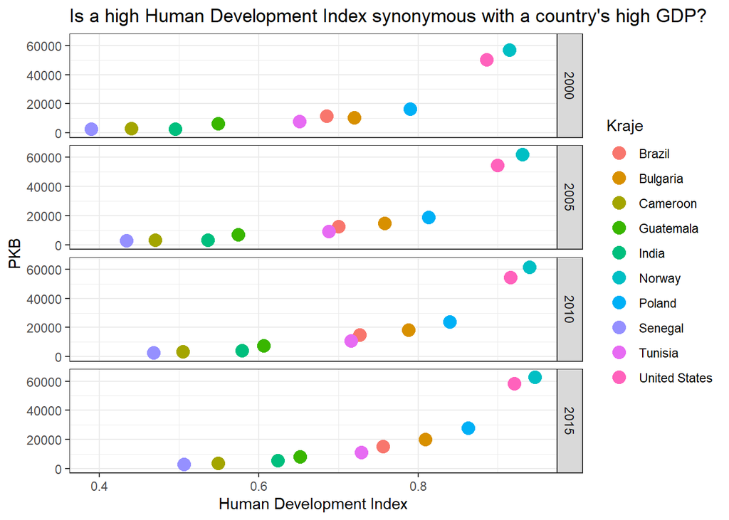

```r
dane_wykres1 %>%
  ggplot() +
  geom_point(mapping = aes(x = dane_wykres1$hdi, y = dane_wykres1$gdp, color = as.factor(dane_wykres1$country)), size = 4) +
  ggtitle("Is a high Human Development Index synonymous with a country's high GDP?") +
  labs(y = "PKB",
       x = "Human Development Index",
       color = "Kraje") + facet_grid(year~.)+
  ylim(0,65000)+theme_bw()
```

```r
cor(dane_wykres1$gdp,dane_wykres1$hdi, method = "spearman")
```

```
## [1] 0.9877574
```

```r
cor(dane_wykres1$gdp,dane_wykres1$hdi, method = "pearson")
```

```
## [1] 0.861907
```

# Question 2: Does a country’s high GDP equate to its low social differentiation?

```r
wykres2
```

```
##      srednia1 odchylenie1 zmiennosc1
## Gini     0.47        0.12      25.53
## PKB  13448.18    15255.59     113.44
```

```r
summary(dane_wykres2)
```

```
##    country              ginni             gdp
##  Length:110         Min.   :0.2300   Min.   : 1380
##  Class :character   1st Qu.:0.3000   1st Qu.: 2998
##  Mode  :character   Median :0.5100   Median : 7105
##                     Mean   :0.4688   Mean   :13448
##                     3rd Qu.:0.5800   3rd Qu.:14475
##                     Max.   :0.6000   Max.   :64100
```

```r
round(cor(x1,y1,method = "spearman"),3)
```

```
## [1] 0.12
```

```r
round(cor(x1,y1,method = "pearson"),3)
```

```
## [1] 0.196
```

```r
#Dla wszystkich państw z gapmindera
round(cor(dane_wykres2.1$ginni,dane_wykres2.1$gdp,method = "pearson"),3)
```

```
## [1] -0.084
```

```r
round(cor(dane_wykres2.1$ginni,dane_wykres2.1$gdp,method = "spearman"),3)
```

```
## [1] -0.102
```

Because a high Gini index indicates a large social differentiation in a country, the low Pearson and Spearman correlation tells us that there is a very weak dependence between the Gini index and GDP. That is, if social differentiation deepens in a country, the GDP does not increase, in the case that we considered a larger number of countries, the dependencies should come out negative this indicates that as the dependence decreases GDP should increase.

# Question 3: Checking the change in GDP size in selected countries over the years

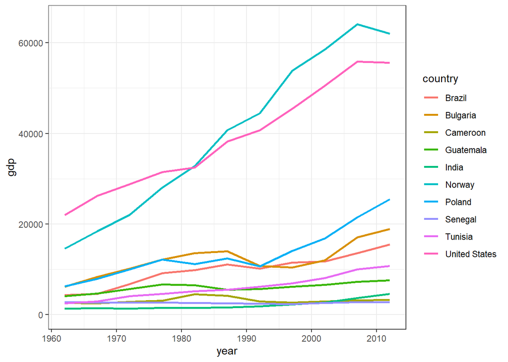

```r
dane_wykres3 %>%
  ggplot(aes(x = year, y = gdp, col = country)) +
  geom_line(size = 1) + xlim(1962,2012)+
  ylim(0,65000)+theme_bw()
```

```r
wyniki2 <- data.frame(srednia2, odchylenie2, zmiennosc2)
rownames(wyniki2)<-c("Bulgaria", "Brazylia", "Kamerun", "Gwatemala", "Indie", "Norwegia", "Polska", "Senegal", "Tunezja", "USA")
wyniki2
```

```
##            srednia2 odchylenie2 zmiennosc2
## Bulgaria  12161.818   3660.0569   30.09465
## Brazylia   9851.818   3496.2632   35.48851
## Kamerun    3181.818    628.5987   19.75596
## Gwatemala  6050.000   1044.3371   17.26177
## Indie      2168.182   1071.1846   49.40474
## Norwegia  39972.727  18018.2736   45.07642
## Polska    13510.909   5749.8182   42.55686
## Senegal    2636.364    142.8477    5.41836
## Tunezja    6093.636   2679.9898   43.98014
## USA       38854.545  11808.2483   30.39091
```

From the chart, one can easily determine which countries belong to which group of developing countries. It is clear to see steadily and vigorously developing states like the USA and Norway, while the rest of the countries are relatively close to each other. The GDP of Poland, Bulgaria, and Brazil in the 1990+ maintains an upward trend, while the countries below them on the chart cannot boast the same. It is worth paying attention to the calculated descriptive statistics, as you can notice that in most countries, the variability occurs at an average level, but there are quite large standard deviations for very developed countries, and this results from their large increases over these 50 years.

# Question 4: How does the expected lifespan change in selected countries?

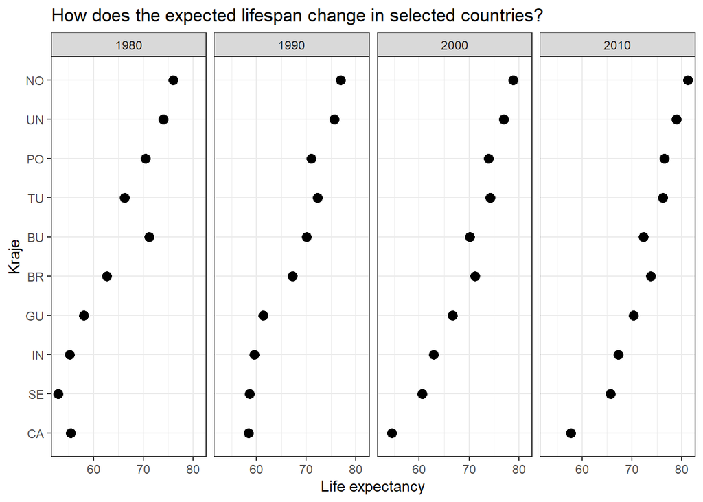

```r
dane_wykres4$kraj <- dane_wykres4$country %>%
  substr(start = 1, stop = 2) %>%
  toupper()

dane_wykres4 %>%
  ggplot(aes(y = reorder(kraj, dlzycia),
             x = dlzycia),
         fill = continent) +
  geom_point(size = 3, col = "black") +
  labs(y = "Kraje",x = "Life expectancy")+
  ggtitle("How does the expected lifespan change in selected countries?")+
  facet_grid(.~year)+theme_bw()
```

# Question 5: Checking the relationship between HDI and child mortality within the first year of life (per 1000 births)

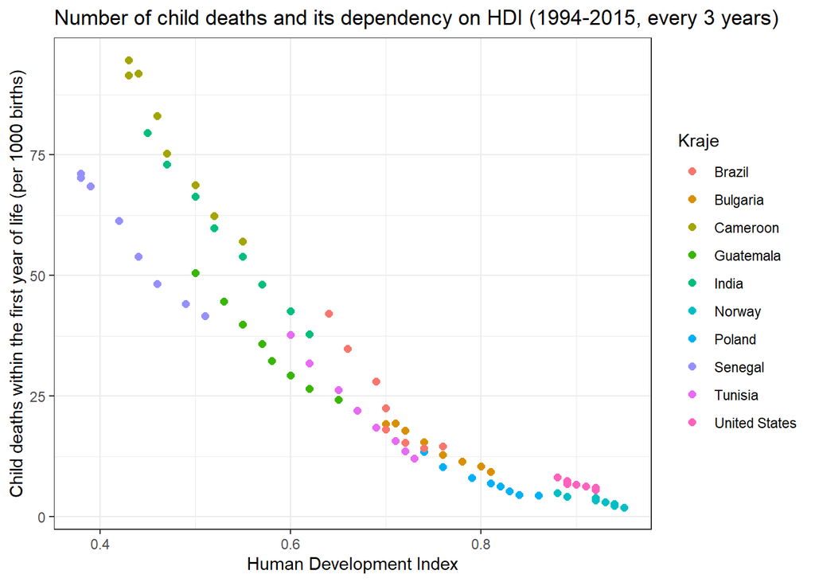

```r
dane_wykres5 %>%
  ggplot() +
  geom_point(mapping = aes(x = hdi, y = zgonyDZ, color = as.factor(country)), size = 2) +
  ggtitle("Number of child deaths and its dependency on HDI (1994-2015, every 3 years)") +
  labs(y = "Child deaths within the first year of life (per 1000 births)",
       x = "Human Development Index",
       color = "Kraje")+theme_bw()
```

# Question 6: Is it true that over the years the birth rate decreases as parents prioritize their careers?

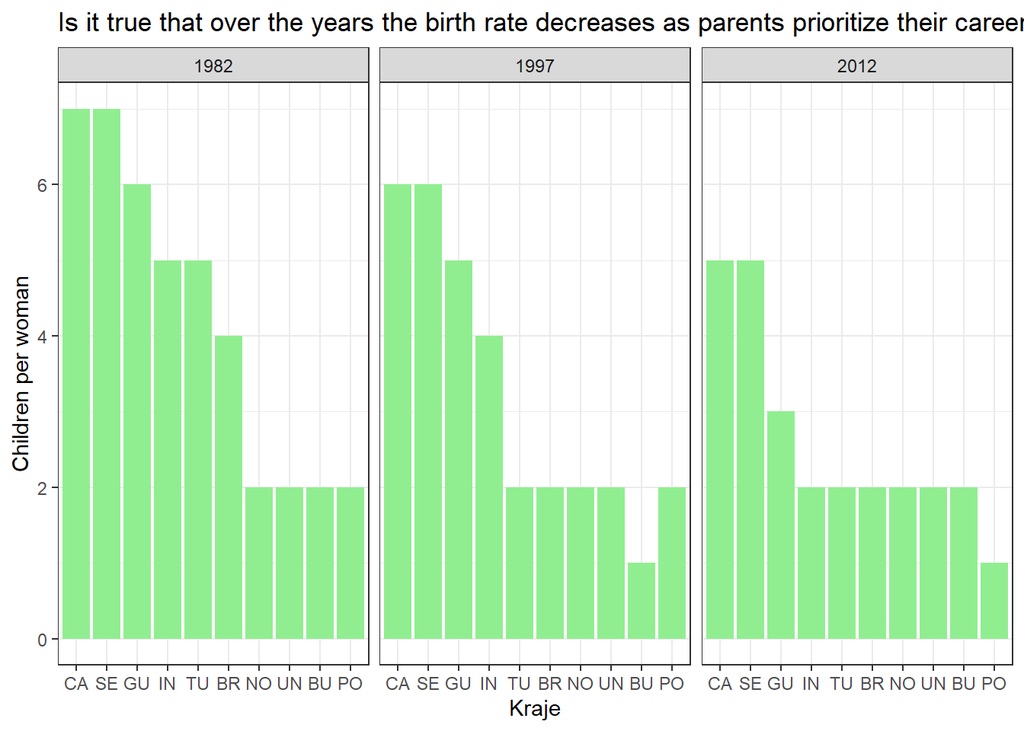

```r
dane_wykres6$kraj <- dane_wykres6$country %>%
  substr(start = 1, stop = 2) %>%
  toupper()

dane_wykres6 %>%
  ggplot() +
  geom_col(mapping = aes(x = reorder(kraj, -dzieci), y = dzieci), fill="light green")+
  ggtitle("Is it true that over the years the birth rate decreases as parents prioritize their careers?")+
  labs(y = "Children per woman",
       x = "Kraje")+
  facet_grid(.~year)+theme_bw()
```

As can be observed, the number of children born to women shows a downward trend or the numbers remain low. This may be due to the fact that women are becoming increasingly independent and aspire to have their own professional careers rather than just taking care of the home as was the case in the past. There is a commonly discussed demographic crisis not only in Poland but also worldwide. Of course, there are some exceptions such as some smaller African countries where a woman has a very large number of children, but due to a lack of proper hygiene and medical care, some unfortunately die.

# Question 7: Do people increasingly value education?

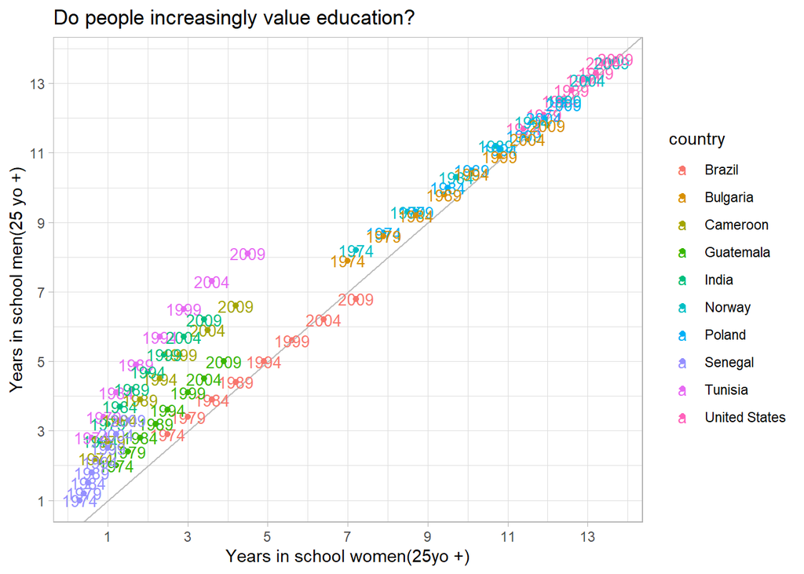

```r
wykres7 <-ggplot(data = dane_wykres7, aes(x=szkolaK, y=szkolaCH, color=country, label=year)) +
  geom_point() +
  xlab("Years in school women(25yo +)") +
  ylab("Years in school men(25 yo +)") +
  ggtitle("Do people increasingly value education?") +
  geom_abline(slope = 1, intercept = 0, color = "grey")+
  scale_x_continuous(breaks=seq(1,15,by=2))+
  scale_y_continuous(breaks=seq(1,15,by=2))+
  theme_light()

wykres7 + geom_text(size=3.5)
```

A growing trend in education is observed in every country discussed, with the right side of the chart, in countries such as Poland, the USA, Bulgaria, and Norway, showing similar increases in education years between women and men. In contrast, in less developed countries, it’s clear that men place more emphasis on education. Generally speaking, year after year, more people are placing greater importance on proper education. It’s worth noting the increases on the women’s side, which may directly relate to the previously discussed issue of lower birth rates.